# Dataframes and Loading Data

Vineet Abraham

April 16, 2015

This document will go over some of the basic functionality in R. It can be used in a couple of ways. You can press the **Knit HTML** button in the toolbar to view the entire document either in the viewer pane in the bottom-right of the RStudio interactive development environment (IDE) or in a separate HTML window. You can select the output type by pressing the down arrow to the right of the **Knit HTML** button.

[figure not shown]

You can also run through the code in this document line-by-line by pressing the **Run** button, or chunk-by-chunk by pressing the **Chunks** button in the toolbar and then selecting **Run Next Chunk**.

[figure not shown]

These tutorial documents are meant to build upon each other so please make sure to review any earlier documents prior to starting this one.

### Creating a dataframe from scratch

Dataframes are at the core of data analysis in R. They differ from matrices in that each column can be of a different data type. Matrices generally contain only numeric values. They can be created in multiple ways. The most basic way to create a dataframe is using the data.frame() command. Check out the help function - ?data.frame, for additional details. Note that the number of rows must be the same for all columns in a matrix.

```r
# Create a sample dataframe of athlete data
a.name <- c("Vin", "Mel", "Don", "Sal", "Sonny", "Arbita")
a.age <- c(23, 31, 21, 27, 34, 24)
a.height <- c(66, 69, 71, 70, 73, 71) #in inches
a.weight <- c(160, 178, 155, 160, 180, 158)
# Without specifying that a.sex is factor, R will automatically assume individual string characters.
a.sex <- as.factor(c("male", "male", "male", "female", "male", "female"))
# Combine all the vectors into a single dataframe
df <- data.frame(a.name, a.age, a.height, a.weight, a.sex)
# Print the dataframe
df
```

```
##   a.name a.age a.height a.weight  a.sex
## 1    Vin    23       66      160   male
## 2    Mel    31       69      178   male
## 3    Don    21       71      155   male
## 4    Sal    27       70      160 female
## 5  Sonny    34       73      180   male
## 6 Arbita    24       71      158 female
```

```r
# Check out the dataframe class
class(df)
```

```
## [1] "data.frame"
```

```r
# Check out the class of the individual dataframe columns
str(df)
```

```
## 'data.frame':    6 obs. of  5 variables:
##  $ a.name  : Factor w/ 6 levels "Arbita","Don",..: 6 3 2 4 5 1
##  $ a.age   : num  23 31 21 27 34 24
##  $ a.height: num  66 69 71 70 73 71
##  $ a.weight: num  160 178 155 160 180 158
##  $ a.sex   : Factor w/ 2 levels "female","male": 2 2 2 1 2 1
```

```r
# See additional details about the dataframe using the summary() command
summary(df)
```

```
##     a.name      a.age          a.height        a.weight        a.sex
##  Arbita:1   Min.   :21.00   Min.   :66.00   Min.   :155.0   female:2
##  Don   :1   1st Qu.:23.25   1st Qu.:69.25   1st Qu.:158.5   male  :4
##  Mel   :1   Median :25.50   Median :70.50   Median :160.0
##  Sal   :1   Mean   :26.67   Mean   :70.00   Mean   :165.2
##  Sonny :1   3rd Qu.:30.00   3rd Qu.:71.00   3rd Qu.:173.5
##  Vin   :1   Max.   :34.00   Max.   :73.00   Max.   :180.0
```

Dataframes can also come from other sources. R has an internal library of dataframes to use.

```r
# List the internal library of R datasets
data()
```

### Uploading a dataframe from a local source

You can import dataframes directly from a local source. Under **Files** in the bottom-right panel, click **Upload** to upload files directly to the server. Files will automatically appear in the working directory of the RStudio server instance you are running. To check where that directory is, type `getwd()`. All the files you create and save will appear in this directory.

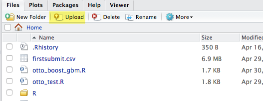

To read the data from the source file, you can use the read.table() command. Check out the help command `?read.table` for more information. There should be a file called “cardata.csv” in the working directory, you can load it into RStudio as follows.

```r
car <- read.csv("/home/radmin/Tutorials/data_images/cardata.csv")
```

The dataframe “car” should now appear in the global environment section of RStudio

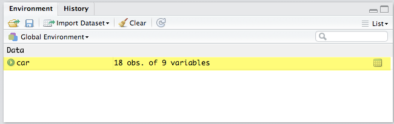

### Importing dataframes from the internet

You can import dataframes from the internet using the read.table() commands as well, just replace the local directory path with a url.

```r
# Load credit screening data from the UCI machine learning repository.
url="http://archive.ics.uci.edu/ml/machine-learning-databases/credit-screening/crx.data"
mydata=read.csv(url, header=FALSE)
```

### Exploring a dataframe

Once you’ve loaded a dataframe, you can begin to explore to explore the data. We’ve looked at some of these commands above like `str()` and `summary()`.

```r
# Get a summary of the car dataset
summary(car)
```

```
##       mpg          cylinders      displacement     horsepower
##  Min.   :14.00   Min.   :4.000   Min.   :113.0   Min.   : 85.0
##  1st Qu.:14.25   1st Qu.:8.000   1st Qu.:302.5   1st Qu.:132.5
##  Median :15.00   Median :8.000   Median :345.0   Median :155.0
##  Mean   :16.61   Mean   :7.444   Mean   :335.4   Mean   :158.9
##  3rd Qu.:18.00   3rd Qu.:8.000   3rd Qu.:421.8   3rd Qu.:196.0
##  Max.   :24.00   Max.   :8.000   Max.   :455.0   Max.   :225.0
##
##      weight      acceleration      model.year     origin
##  Min.   :2372   Min.   : 8.000   Min.   :70   Min.   :1.000
##  1st Qu.:3173   1st Qu.: 9.625   1st Qu.:70   1st Qu.:1.000
##  Median :3534   Median :10.250   Median :70   Median :1.000
##  Mean   :3521   Mean   :11.250   Mean   :70   Mean   :1.111
##  3rd Qu.:3828   3rd Qu.:12.000   3rd Qu.:70   3rd Qu.:1.000
##  Max.   :4425   Max.   :16.000   Max.   :70   Max.   :3.000
##
##                         car.name
##  "amc ambassador dpl"       : 1
##  "amc hornet"               : 1
##  "amc rebel sst"            : 1
##  "buick estate wagon (sw)"  : 1
##  "buick skylark 320"        : 1
##  "chevrolet chevelle malibu": 1
##  (Other)                    :12
```

```r
# Display the data structure
str(car)
```

```
## 'data.frame':    18 obs. of  9 variables:
##  $ mpg         : int  18 15 18 16 17 15 14 14 14 15 ...
##  $ cylinders   : int  8 8 8 8 8 8 8 8 8 8 ...
##  $ displacement: int  307 350 318 304 302 429 454 440 455 390 ...
##  $ horsepower  : int  130 165 150 150 140 198 220 215 225 190 ...
##  $ weight      : int  3504 3693 3436 3433 3449 4341 4354 4312 4425 3850 ...
##  $ acceleration: num  12 11.5 11 12 10.5 10 9 8.5 10 8.5 ...
##  $ model.year  : int  70 70 70 70 70 70 70 70 70 70 ...
##  $ origin      : int  1 1 1 1 1 1 1 1 1 1 ...
##  $ car.name    : Factor w/ 18 levels "\"amc ambassador dpl\"",..: 6 5 16 3 12 10 7 15 17 1 ...
```

```r
# Get the names of all the columns in the dataset
names(car)
```

```
## [1] "mpg"          "cylinders"    "displacement" "horsepower"
## [5] "weight"       "acceleration" "model.year"   "origin"
## [9] "car.name"
```

```r
# Display the first 6 rows of the dataframe
head(car)
```

```
##   mpg cylinders displacement horsepower weight acceleration model.year
## 1  18         8          307        130   3504         12.0         70
## 2  15         8          350        165   3693         11.5         70
## 3  18         8          318        150   3436         11.0         70
## 4  16         8          304        150   3433         12.0         70
## 5  17         8          302        140   3449         10.5         70
## 6  15         8          429        198   4341         10.0         70
##   origin                    car.name
## 1      1 "chevrolet chevelle malibu"
## 2      1         "buick skylark 320"
## 3      1        "plymouth satellite"
## 4      1             "amc rebel sst"
## 5      1               "ford torino"
## 6      1          "ford galaxie 500"
```

```r
# Display the last 6 rows of the dataframe
tail(car)
```

```
##    mpg cylinders displacement horsepower weight acceleration model.year
## 13  15         8          400        150   3761          9.5         70
## 14  14         8          455        225   3086         10.0         70
## 15  24         4          113         95   2372         15.0         70
## 16  22         6          198         95   2833         15.5         70
## 17  18         6          199         97   2774         15.5         70
## 18  21         6          200         85   2587         16.0         70
##    origin                  car.name
## 13      1   "chevrolet monte carlo"
## 14      1 "buick estate wagon (sw)"
## 15      3   "toyota corona mark ii"
## 16      1         "plymouth duster"
## 17      1              "amc hornet"
## 18      1           "ford maverick"
```

```r
# Count the number of rows
nrow(car)
```

```
## [1] 18
```

```r
# Count the number of columns
ncol(car)
```

```
## [1] 9
```

```r
# View individual rows
car[1,]
```

```
##   mpg cylinders displacement horsepower weight acceleration model.year
## 1  18         8          307        130   3504           12         70
##   origin                    car.name
## 1      1 "chevrolet chevelle malibu"
```

```r
car[2,]
```

```
##   mpg cylinders displacement horsepower weight acceleration model.year
## 2  15         8          350        165   3693         11.5         70
##   origin            car.name
## 2      1 "buick skylark 320"
```

```r
# View individual columns
car[,1]
```

```
##  [1] 18 15 18 16 17 15 14 14 14 15 15 14 15 14 24 22 18 21
```

```r
car[,2]
```

```
##  [1] 8 8 8 8 8 8 8 8 8 8 8 8 8 8 4 6 6 6
```

```r
# You can also use the "$" and "tab" after the dataframe to view individual columns
car$mpg
```

```
##  [1] 18 15 18 16 17 15 14 14 14 15 15 14 15 14 24 22 18 21
```

```r
car$cylinders
```

```
##  [1] 8 8 8 8 8 8 8 8 8 8 8 8 8 8 4 6 6 6
```

[figure not shown]

```r
# Selecting multiple rows
car[1:4,]
```

```
##   mpg cylinders displacement horsepower weight acceleration model.year
## 1  18         8          307        130   3504         12.0         70
## 2  15         8          350        165   3693         11.5         70
## 3  18         8          318        150   3436         11.0         70
## 4  16         8          304        150   3433         12.0         70
##   origin                    car.name
## 1      1 "chevrolet chevelle malibu"
## 2      1         "buick skylark 320"
## 3      1        "plymouth satellite"
## 4      1             "amc rebel sst"
```

```r
# Selecting multiple columns
car[,1:2]
```

```
##    mpg cylinders
## 1   18         8
## 2   15         8
## 3   18         8
## 4   16         8
## 5   17         8
## 6   15         8
## 7   14         8
## 8   14         8
## 9   14         8
## 10  15         8
## 11  15         8
## 12  14         8
## 13  15         8
## 14  14         8
## 15  24         4
## 16  22         6
## 17  18         6
## 18  21         6
```

```r
# Selecting different rows
car[c(1,3,4,6),]
```

```
##   mpg cylinders displacement horsepower weight acceleration model.year
## 1  18         8          307        130   3504           12         70
## 3  18         8          318        150   3436           11         70
## 4  16         8          304        150   3433           12         70
## 6  15         8          429        198   4341           10         70
##   origin                    car.name
## 1      1 "chevrolet chevelle malibu"
## 3      1        "plymouth satellite"
## 4      1             "amc rebel sst"
## 6      1          "ford galaxie 500"
```

```r
# Selecting different columns
car[,c(1,3)]
```

```
##    mpg displacement
## 1   18          307
## 2   15          350
## 3   18          318
## 4   16          304
## 5   17          302
## 6   15          429
## 7   14          454
## 8   14          440
## 9   14          455
## 10  15          390
## 11  15          383
## 12  14          340
## 13  15          400
## 14  14          455
## 15  24          113
## 16  22          198
## 17  18          199
## 18  21          200
```

```r
# Selecting individual elements of a dataframe
car[1,1]
```

```
## [1] 18
```

```r
car[1,"mpg"]
```

```
## [1] 18
```